# Applied Example - HIP Study

## Hypothesis Testing - HIP Study

### Importing the necessary libraries

```python
import scipy.stats as stats
import numpy as np
import matplotlib.pyplot as plt
from statsmodels.stats.proportion import proportions_ztest
import seaborn as sns
from scipy.stats import binom
```

| Group size | Breast Cancer |  | All Other |
| --- | --- | --- | --- |
|  | No. , Rate |  | No. , Rate |
| Treatment |  |  |  |
| Screened 20,200 | 23 , 1.1 |  | 428 , 21 |
| Refused 10,800 | 16 , 1.5 |  | 409 , 38 |
| Total 31,000 | 39 , 1.3 |  | 837 , 27 |
| Control 31,000 | 63 , 2.0 |  | 879 , 28 |

**We are performing the hypothesis test to check whether the difference in death rates between the treatment and control group is sufficient to establish that offering mammography reduces the risk of death from breast cancer**

#### Binomial Distribution

**Null hypothesis (H0): π = 0.002**

**Alternative (HA): π < 0.002**

- Total nuber of trials/observations = 31,000
- Hypothesized probability = 0.002
- Number of trials/observations = 39

```python
print("The p-value is",round(stats.binom_test(x = 39 , n = 31000, p = 0.002 , alternative = "less" ),4))
```

```
The p-value is 0.0012
```

Because the p-value (0.0012) is less than 0.05, we reject the null hypothesis i.e. we have sufficient evidence to say the mammography reduces the risk of death from breast cancer.

```python
n = 31000
p = 0.002
k = np.arange(0,200)
dist  = [binom.pmf(i, n, p) for i in k]
```

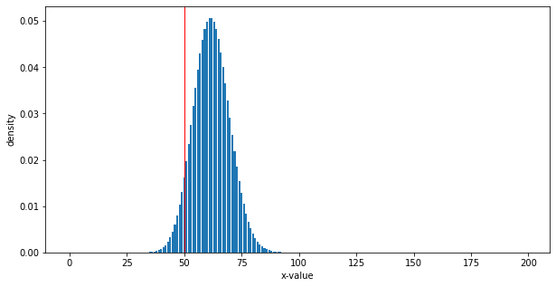

```python
plt.figure(figsize=(10,5))
plt.bar(k, dist)
plt.axvline(50, color='red', linestyle='-', linewidth=1)
plt.xlabel("x-value")
plt.ylabel("density")
plt.show()
```

#### Normal Distribution

**Null hypothesis (H0): π = 0.002**

**Alternative (HA): π < 0.002**

- count: the number of successes in trials/observations
- nobs: the number of trials/observations
- value: value of the null hypothesis(proportion)

```python
stat , pvalue = proportions_ztest(count=39, nobs=31000,value=0.002,alternative="smaller")
```

```python
print("The p-value is",pvalue)
```

```
The p-value is 0.00011423176454888235
```

Because the p-value (0.00011) is less than 0.05, we reject the null hypothesis i.e. we have sufficient evidence to say the mammography reduces the risk of death from breast cancer.

**Hence we can conclude that this study suggests that offering mammography is indeed helpful and can reduce the risk of death from Breast Cancer.**